# Projet Mathématiques pour le Big Data — Optimisation, Pseudo-inverse, ACP, AFC

## 3.2 Exercice 3.2.2 : $f(x,y,z) = x^2+y^2+z^2$ sous $g_1 = x+y+z-1=0$ et $g_2 = z=0$

```r
cat("Lagrangien : L = x²+y²+z² - λ₁(x+y+z-1) - λ₂(z)\n\n")
```

```
## Lagrangien : L = x²+y²+z² - λ₁(x+y+z-1) - λ₂(z)
```

```r
cat("dL/dx = 2x - λ₁ = 0       => x = λ₁/2\n")
```

```
## dL/dx = 2x - λ₁ = 0       => x = λ₁/2
```

```r
cat("dL/dy = 2y - λ₁ = 0       => y = λ₁/2\n")
```

```
## dL/dy = 2y - λ₁ = 0       => y = λ₁/2
```

```r
cat("dL/dz = 2z - λ₁ - λ₂ = 0  => z = (λ₁+λ₂)/2\n")
```

```
## dL/dz = 2z - λ₁ - λ₂ = 0  => z = (λ₁+λ₂)/2
```

```r
cat("g₂ : z = 0  =>  λ₂ = -λ₁\n")
```

```
## g₂ : z = 0  =>  λ₂ = -λ₁
```

```r
cat("g₁ : x + y + z = 1  =>  λ₁/2 + λ₁/2 + 0 = 1  =>  λ₁ = 1\n\n")
```

```
## g₁ : x + y + z = 1  =>  λ₁/2 + λ₁/2 + 0 = 1  =>  λ₁ = 1
```

```r
x0 <- 1/2; y0 <- 1/2; z0 <- 0
cat("Point critique : (", x0, ",", y0, ",", z0, ")\n")
```

```
## Point critique : ( 0.5 , 0.5 , 0 )
```

```r
cat("f(1/2, 1/2, 0) =", x0^2 + y0^2 + z0^2, "\n\n")
```

```
## f(1/2, 1/2, 0) = 0.5
```

```r
# Hessienne bordée
HL <- diag(2, 3) # Hessienne du Lagrangien = 2I₃
Dg <- rbind(c(1,1,1), c(0,0,1))
H_bordee <- rbind(
  cbind(matrix(0, 2, 2), Dg),
  cbind(t(Dg), HL)
)
cat("Hessienne bordée (5×5) :\n")
```

```
## Hessienne bordée (5×5) :
```

```r
print(H_bordee)
```

```
##      [,1] [,2] [,3] [,4] [,5]
## [1,]    0    0    1    1    1
## [2,]    0    0    0    0    1
## [3,]    1    0    2    0    0
## [4,]    1    0    0    2    0
## [5,]    1    1    0    0    2
```

```r
det_H <- det(H_bordee)
cat("\ndet(H) =", det_H, "\n")
```

```
##
## det(H) = 4
```

```r
# n=3, p=2 => n-p=1 dernier mineur principal
# det(H) du signe de (-1)^p = (-1)^2 = 1 => minimum
cat("(-1)^p = (-1)^2 = 1. det(H) =", det_H, "> 0 => MINIMUM LOCAL\n")
```

```
## (-1)^p = (-1)^2 = 1. det(H) = 4 > 0 => MINIMUM LOCAL
```

```r
cat("=> f(1/2, 1/2, 0) = 1/2 est un minimum sous contraintes.\n")
```

```
## => f(1/2, 1/2, 0) = 1/2 est un minimum sous contraintes.
```

## 3.3 Exercice 3.2.3 : $f = x^2+y^2+z^2$ sous $g_1 = x^2+y^2+2z-6=0$ et $g_2 = x-y-z=0$

```r
cat("Lagrangien : L = x²+y²+z² - λ₁(x²+y²+2z-6) - λ₂(x-y-z)\n\n")
```

```
## Lagrangien : L = x²+y²+z² - λ₁(x²+y²+2z-6) - λ₂(x-y-z)
```

```r
cat("dL/dx = 2x - 2λ₁x - λ₂ = 0\n")
```

```
## dL/dx = 2x - 2λ₁x - λ₂ = 0
```

```r
cat("dL/dy = 2y - 2λ₁y + λ₂ = 0\n")
```

```
## dL/dy = 2y - 2λ₁y + λ₂ = 0
```

```r
cat("dL/dz = 2z - 2λ₁ + λ₂ = 0\n\n")
```

```
## dL/dz = 2z - 2λ₁ + λ₂ = 0
```

```r
cat("Résolution numérique des points critiques :\n")
```

```
## Résolution numérique des points critiques :
```

```r
# On cherche les solutions du système
# En additionnant eq1 et eq2 : 2(x+y)(1-λ₁) = 0
# Cas 1: λ₁ = 1 => eq3: 2z - 2 + λ₂ = 0 => λ₂ = 2-2z
# eq1: 2x - 2x - (2-2z) = 0 => 2z-2 = 0 => z = 1
# g2: x - y - 1 = 0 => x = y+1
# g1: x²+y²+2-6 = 0 => (y+1)²+y² = 4 => 2y²+2y-3 = 0
# y = (-2 ± sqrt(4+24))/4 = (-2 ± sqrt(28))/4
y_sol <- (-2 + sqrt(28))/4
x_sol <- y_sol + 1
z_sol <- 1
cat("\nCas λ₁ = 1 :\n")
```

```
##
## Cas λ₁ = 1 :
```

```r
cat("  Point 1 : (", round(x_sol,4), ",", round(y_sol,4), ",", z_sol, ")\n")
```

```
##   Point 1 : ( 1.8229 , 0.8229 , 1 )
```

```r
cat("  f =", round(x_sol^2 + y_sol^2 + z_sol^2, 4), "\n")
```

```
##   f = 5
```

```r
y_sol2 <- (-2 - sqrt(28))/4
x_sol2 <- y_sol2 + 1
cat("  Point 2 : (", round(x_sol2,4), ",", round(y_sol2,4), ",", z_sol, ")\n")
```

```
##   Point 2 : ( -0.8229 , -1.8229 , 1 )
```

```r
cat("  f =", round(x_sol2^2 + y_sol2^2 + z_sol^2, 4), "\n")
```

```
##   f = 5
```

```r
# Cas 2 : x + y = 0 => y = -x
# g2: x - (-x) - z = 0 => z = 2x
# g1: x² + x² + 4x - 6 = 0 => 2x² + 4x - 6 = 0 => x² + 2x - 3 = 0
# x = (-2 ± sqrt(4+12))/2 = (-2 ± 4)/2
cat("\nCas x + y = 0 :\n")
```

```
##
## Cas x + y = 0 :
```

```r
x_a <- 1; y_a <- -1; z_a <- 2
cat("  Point 3 : (", x_a, ",", y_a, ",", z_a, ")\n")
```

```
##   Point 3 : ( 1 , -1 , 2 )
```

```r
cat("  f =", x_a^2 + y_a^2 + z_a^2, "\n")
```

```
##   f = 6
```

```r
x_b <- -3; y_b <- 3; z_b <- -6
cat("  Point 4 : (", x_b, ",", y_b, ",", z_b, ")\n")
```

```
##   Point 4 : ( -3 , 3 , -6 )
```

```r
cat("  f =", x_b^2 + y_b^2 + z_b^2, "\n")
```

```
##   f = 54
```

```r
# Nature des points
cat("\nAnalyse de la nature des points par Hessienne bordée :\n")
```

```
##
## Analyse de la nature des points par Hessienne bordée :
```

```r
for (pt in list(c(x_a, y_a, z_a), c(x_b, y_b, z_b))) {
  Dg_pt <- rbind(
    c(2*pt[1], 2*pt[2], 2),
    c(1, -1, -1)
  )
  HL_pt <- diag(2, 3) # Hessienne constante = 2I
  H_bord <- rbind(
    cbind(matrix(0, 2, 2), Dg_pt),
    cbind(t(Dg_pt), HL_pt)
  )
  d <- det(H_bord)
  cat("  Point (", pt[1], ",", pt[2], ",", pt[3], ") : det(H) =", round(d, 4), "\n")
}
```

```
##   Point ( 1 , -1 , 2 ) : det(H) = 64
##   Point ( -3 , 3 , -6 ) : det(H) = 64
```

```r
cat("=> (1,-1,2) avec f = 6 : minimum local\n")
```

[output not shown]

```r
cat("=> (-3,3,-6) avec f = 54 : maximum local\n")
```

```
## => (-3,3,-6) avec f = 54 : maximum local
```

## 3.4 Exercice 3.2.4 : $f(x,y) = x^2 y$ sous $2x^2 + y^2 = 3$

```r
cat("Lagrangien : L = x²y - λ(2x² + y² - 3)\n\n")
```

```
## Lagrangien : L = x²y - λ(2x² + y² - 3)
```

```r
cat("dL/dx = 2xy - 4λx = 0  => 2x(y - 2λ) = 0\n")
```

```
## dL/dx = 2xy - 4λx = 0  => 2x(y - 2λ) = 0
```

```r
cat("dL/dy = x² - 2λy = 0   => λ = x²/(2y)\n")
```

```
## dL/dy = x² - 2λy = 0   => λ = x²/(2y)
```

```r
cat("Contrainte : 2x² + y² = 3\n\n")
```

```
## Contrainte : 2x² + y² = 3
```

```r
# Cas x = 0 => y² = 3 => y = ±√3, f = 0
# Cas y = 2λ => λ = x²/(2y) => y = x²/y => y² = x²
# => y = ±x. Avec 2x² + x² = 3 => x² = 1

pts <- data.frame(
  x = c(0, 0, 1, -1, 1, -1),
  y = c(sqrt(3), -sqrt(3), 1, 1, -1, -1),
  stringsAsFactors = FALSE
)
pts$f <- pts$x^2 * pts$y

cat("Points critiques :\n")
```

```
## Points critiques :
```

```r
for (i in 1:nrow(pts)) {
  cat(sprintf("  (%6.3f, %6.3f) : f = %6.3f\n", pts$x[i], pts$y[i], pts$f[i]))
}
```

```
##   ( 0.000,  1.732) : f =  0.000
##   ( 0.000, -1.732) : f = -0.000
##   ( 1.000,  1.000) : f =  1.000
##   (-1.000,  1.000) : f =  1.000
##   ( 1.000, -1.000) : f = -1.000
##   (-1.000, -1.000) : f = -1.000
```

```r
cat("\n=> Maximum : f = 1 en (±1, 1)\n")
```

```
##
## => Maximum : f = 1 en (±1, 1)
```

```r
cat("=> Minimum : f = -1 en (±1, -1)\n")
```

```
## => Minimum : f = -1 en (±1, -1)
```

### 3.4.1 Tracé

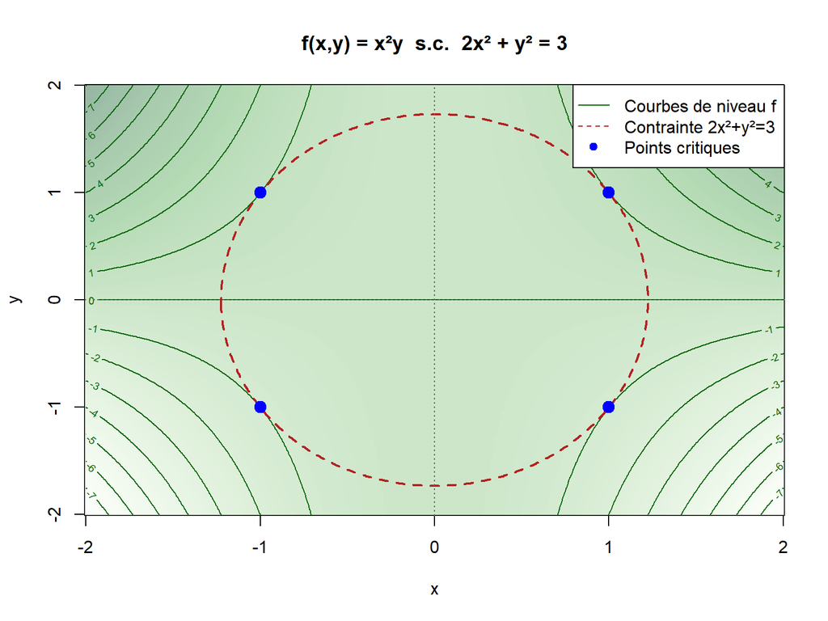

```r
f3_4 <- function(x, y) x^2 * y
g3_4 <- function(x, y) 2*x^2 + y^2 - 3

x_seq <- seq(-2, 2, length.out = 300)
y_seq <- seq(-2, 2, length.out = 300)
z_mat <- outer(x_seq, y_seq, f3_4)

image(x_seq, y_seq, z_mat,
      col = hcl.colors(100, "Greens", rev = TRUE, alpha = 0.4),
      xlab = "x", ylab = "y",
      main = "f(x,y) = x²y  s.c.  2x² + y² = 3")
contour(x_seq, y_seq, z_mat, nlevels = 20, col = "darkgreen", add = TRUE, drawlabels = TRUE)
g_mat <- outer(x_seq, y_seq, g3_4)
contour(x_seq, y_seq, g_mat, levels = 0, col = "firebrick", lwd = 2, lty = 2,
        add = TRUE, drawlabels = FALSE)
points(c(1,-1,1,-1), c(1,1,-1,-1), pch = 19, col = "blue", cex = 1.5)
abline(h = 0, v = 0, col = "gray40", lty = 3)
legend("topright",
       legend = c("Courbes de niveau f", "Contrainte 2x²+y²=3", "Points critiques"),
       col = c("darkgreen", "firebrick", "blue"),
       lty = c(1, 2, NA), pch = c(NA, NA, 19), bg = "white")
```

## 3.5 Exercice 3.2.5 : $f(x,y) = \frac{x^2y^2}{x^2+y^2} + 2x^2+2y^2+4xy+5x+5y+20$ sous $2x^2+2y^2+4xy-8=3$

```r
f3_5 <- function(x, y) {
  r <- x^2 + y^2
  ifelse(r == 0, NA, x^2*y^2/r + 2*x^2 + 2*y^2 + 4*x*y + 5*x + 5*y + 20)
}
g3_5 <- function(x, y) 2*x^2 + 2*y^2 + 4*x*y - 11 # = 0

cat("Contrainte : 2x² + 2y² + 4xy = 11  <=>  2(x+y)² = 11\n")
```

```
## Contrainte : 2x² + 2y² + 4xy = 11  <=>  2(x+y)² = 11
```

```r
cat("=> (x+y)² = 11/2  =>  x+y = ±√(11/2)\n\n")
```

```
## => (x+y)² = 11/2  =>  x+y = ±√(11/2)
```

```r
cat("Sur la contrainte : 2(x+y)² = 11, donc 4xy = 11 - 2x² - 2y²\n")
```

```
## Sur la contrainte : 2(x+y)² = 11, donc 4xy = 11 - 2x² - 2y²
```

```r
cat("Analyse numérique des points critiques...\n\n")
```

```
## Analyse numérique des points critiques...
```

```r
# Points possibles : x + y = sqrt(11/2) ou x + y = -sqrt(11/2)
s <- sqrt(11/2)
cat("Cas x+y =", round(s,4), ":\n")
```

```
## Cas x+y = 2.3452 :
```

```r
cat("  Exemples : x = 0, y =", round(s,4), " => f =", round(f3_5(0, s),4), "\n")
```

```
##   Exemples : x = 0, y = 2.3452  => f = 42.726
```

```r
cat("  x = y =", round(s/2,4), " => f =", round(f3_5(s/2, s/2),4), "\n\n")
```

```
##   x = y = 1.1726  => f = 43.4135
```

```r
cat("Cas x+y =", round(-s,4), ":\n")
```

```
## Cas x+y = -2.3452 :
```

```r
cat("  x = 0, y =", round(-s,4), " => f =", round(f3_5(0, -s),4), "\n")
```

```
##   x = 0, y = -2.3452  => f = 19.274
```

```r
cat("  x = y =", round(-s/2,4), " => f =", round(f3_5(-s/2, -s/2),4), "\n")
```

```
##   x = y = -1.1726  => f = 19.9615
```

### 3.5.1 Tracé

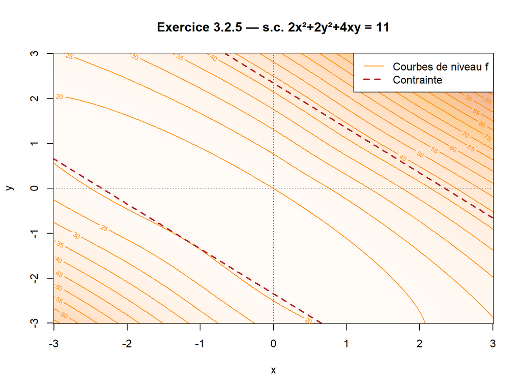

```r
x_seq <- seq(-3, 3, length.out = 300)
y_seq <- seq(-3, 3, length.out = 300)
z_mat <- outer(x_seq, y_seq, f3_5)
z_mat[abs(z_mat) > 200] <- NA

image(x_seq, y_seq, z_mat,
      col = hcl.colors(100, "Oranges", rev = TRUE, alpha = 0.4),
      xlab = "x", ylab = "y",
      main = "Exercice 3.2.5 — s.c. 2x²+2y²+4xy = 11")
contour(x_seq, y_seq, z_mat, nlevels = 20, col = "darkorange", add = TRUE, drawlabels = TRUE)
g_mat <- outer(x_seq, y_seq, g3_5)
contour(x_seq, y_seq, g_mat, levels = 0, col = "firebrick", lwd = 2, lty = 2,
        add = TRUE, drawlabels = FALSE)
abline(h = 0, v = 0, col = "gray40", lty = 3)
legend("topright",
       legend = c("Courbes de niveau f", "Contrainte"),
       col = c("darkorange", "firebrick"), lty = c(1, 2), lwd = c(1, 2), bg = "white")
```

# 4 Exercice 4 — Décomposition en valeurs singulières et pseudo-inverse

## 4.1 Exercice 4.2 : SVD — Cas 1

### 4.1.1 SVD de la matrice A

```r
cat("===== DÉCOMPOSITION SVD DE A (4×4) =====\n\n")
```

```
## ===== DÉCOMPOSITION SVD DE A (4×4) =====
```

```r
A <- matrix(c(-18, 13, -4, 4,
              2, 19, -4, 12,
              -14, 11, -12, 8,
              -2, 21, 4, 8), nrow = 4, byrow = TRUE)
cat("Matrice A :\n"); print(A)
```

```
## Matrice A :
```

```
##      [,1] [,2] [,3] [,4]
## [1,]  -18   13   -4    4
## [2,]    2   19   -4   12
## [3,]  -14   11  -12    8
## [4,]   -2   21    4    8
```

```r
# Étape 1 : A^T A
AtA <- t(A) %*% A
cat("\nA^T A :\n"); print(AtA)
```

```
##
## A^T A :
```

```
##      [,1] [,2] [,3] [,4]
## [1,]  528 -392  224 -176
## [2,] -392 1092 -176  536
## [3,]  224 -176  192 -128
## [4,] -176  536 -128  288
```

```r
# Étape 2 : Diagonalisation de A^T A
eig_A <- eigen(AtA)
cat("\nValeurs propres de A^T A :\n"); print(round(eig_A$values, 4))
```

```
##
## Valeurs propres de A^T A :
```

```
## [1] 1600  400  100    0
```

```r
# Étape 3 : Valeurs singulières
sv_A <- sqrt(abs(eig_A$values))
ordre <- order(sv_A, decreasing = TRUE)
sv_A <- sv_A[ordre]
V_A <- eig_A$vectors[, ordre]
cat("\nValeurs singulières de A (triées) :\n"); print(round(sv_A, 4))
```

```
##
## Valeurs singulières de A (triées) :
```

```
## [1] 40 20 10  0
```

```r
tolerance <- 1e-10
rang_A <- sum(sv_A > tolerance)
cat("Rang de A :", rang_A, "\n")
```

[output not shown]

```r
# Étape 4 : Matrice V
cat("\nMatrice V :\n"); print(round(V_A, 6))
```

```
##
## Matrice V :
```

```
##      [,1] [,2] [,3] [,4]
## [1,]  0.4  0.8  0.4 -0.2
## [2,] -0.8  0.4 -0.2 -0.4
## [3,]  0.2  0.4 -0.8  0.4
## [4,] -0.4  0.2  0.4  0.8
```

```r
# Étape 5 : Matrice U
Ur_A <- matrix(0, nrow = nrow(A), ncol = rang_A)
for (i in 1:rang_A) {
  Av <- A %*% V_A[, i]
  Ur_A[, i] <- Av / sv_A[i]
}
if (rang_A < nrow(A)) {
  U_A <- qr.Q(qr(Ur_A), complete = TRUE)
} else {
  U_A <- Ur_A
}
cat("\nMatrice U :\n"); print(round(U_A, 6))
```

```
##
## Matrice U :
```

```
##      [,1] [,2] [,3] [,4]
## [1,] -0.5 -0.5 -0.5    0
## [2,] -0.5  0.5  0.5    0
## [3,] -0.5 -0.5  0.5    0
## [4,] -0.5  0.5 -0.5    0
```

```r
# Étape 6 : Sigma
Sigma_A <- matrix(0, nrow(A), ncol(A))
for (i in 1:min(rang_A, nrow(A), ncol(A))) Sigma_A[i, i] <- sv_A[i]
cat("\nΣ :\n"); print(round(Sigma_A, 4))
```

```
##
## Σ :
```

```
##      [,1] [,2] [,3] [,4]
## [1,]   40    0    0    0
## [2,]    0   20    0    0
## [3,]    0    0   10    0
## [4,]    0    0    0    0
```

```r
# Vérification
A_recon <- U_A %*% Sigma_A %*% t(V_A)
cat("\nA reconstruite (U Σ V^T) :\n"); print(round(A_recon, 4))
```

```
##
## A reconstruite (U Σ V^T) :
```

```
##      [,1] [,2] [,3] [,4]
## [1,]  -18   13   -4    4
## [2,]    2   19   -4   12
## [3,]  -14   11  -12    8
## [4,]   -2   21    4    8
```

```r
cat("Erreur de reconstruction :", round(norm(A - A_recon, "F"), 10), "\n")
```

```
## Erreur de reconstruction : 0
```

### 4.1.2 SVD de la matrice B

```r
cat("===== DÉCOMPOSITION SVD DE B (4×5) =====\n\n")
```

```
## ===== DÉCOMPOSITION SVD DE B (4×5) =====
```

```r
B <- matrix(c(6, -8, -4, 5, -4,
              2, 7, -5, -6, 4,
              0, -1, -8, 2, 2,
              -1, -2, 4, 4, -8), nrow = 4, byrow = TRUE)
cat("Matrice B :\n"); print(B)
```

```
## Matrice B :
```

```
##      [,1] [,2] [,3] [,4] [,5]
## [1,]    6   -8   -4    5   -4
## [2,]    2    7   -5   -6    4
## [3,]    0   -1   -8    2    2
## [4,]   -1   -2    4    4   -8
```

```r
BtB <- t(B) %*% B
eig_B <- eigen(BtB)
sv_B <- sqrt(abs(eig_B$values))
ordre_B <- order(sv_B, decreasing = TRUE)
sv_B <- sv_B[ordre_B]
V_B <- eig_B$vectors[, ordre_B]
cat("\nValeurs singulières de B :\n"); print(round(sv_B, 4))
```

```
##
## Valeurs singulières de B :
```

```
## [1] 16.4580 12.1595  4.8710  4.3072  0.0000
```

```r
rang_B <- sum(sv_B > tolerance)
rang_B <- min(rang_B, nrow(B), ncol(B))  # Le rang ne peut pas dépasser min(m,n)
cat("Rang de B :", rang_B, "\n")
```

```
## Rang de B : 4
```

```r
Ur_B <- matrix(0, nrow(B), rang_B)
for (i in 1:rang_B) {
  Bv <- B %*% V_B[, i]
  Ur_B[, i] <- Bv / sv_B[i]
}
if (rang_B < nrow(B)) {
  U_B <- qr.Q(qr(Ur_B), complete = TRUE)
} else {
  U_B <- Ur_B
}

Sigma_B <- matrix(0, nrow(B), ncol(B))
for (i in 1:min(rang_B, nrow(B), ncol(B))) Sigma_B[i, i] <- sv_B[i]

B_recon <- U_B %*% Sigma_B %*% t(V_B)
cat("\nB reconstruite :\n"); print(round(B_recon, 4))
```

```
##
## B reconstruite :
```

```
##      [,1] [,2] [,3] [,4] [,5]
## [1,]    6   -8   -4    5   -4
## [2,]    2    7   -5   -6    4
## [3,]    0   -1   -8    2    2
## [4,]   -1   -2    4    4   -8
```

```r
cat("Erreur :", round(norm(B - B_recon, "F"), 10), "\n")
```

```
## Erreur : 0
```

## 4.2 Exercice 4.3 : SVD — Cas 2 (Pseudo-inverse et résolution)

### 4.2.1 Pseudo-inverse de A

```r
cat("===== PSEUDO-INVERSE DE A (4×5) =====\n\n")
```

```
## ===== PSEUDO-INVERSE DE A (4×5) =====
```

```r
A2 <- matrix(c(-3, -3, -6, 6, 1,
               -1, -1, -1, 1, -2,
                0,  0, -1, 1, -1,
                0,  0,  1, 1, -1), nrow = 4, byrow = TRUE)
cat("Matrice A :\n"); print(A2)
```

```
## Matrice A :
```

```
##      [,1] [,2] [,3] [,4] [,5]
## [1,]   -3   -3   -6    6    1
## [2,]   -1   -1   -1    1   -2
## [3,]    0    0   -1    1   -1
## [4,]    0    0    1    1   -1
```

```r
AtA2 <- t(A2) %*% A2
eig2 <- eigen(AtA2)
sv2 <- sqrt(abs(eig2$values))
ord2 <- order(sv2, decreasing = TRUE)
sv2 <- sv2[ord2]
V2 <- eig2$vectors[, ord2]

rang2 <- min(sum(sv2 > 1e-10), nrow(A2), ncol(A2))
cat("\nValeurs singulières :", round(sv2, 4), "\n")
```

```
##
## Valeurs singulières : 9.7685 2.6881 1.2829 0.8396 0
```

```r
cat("Rang de A :", rang2, "\n")
```

```
## Rang de A : 4
```

```r
Vr2 <- V2[, 1:rang2]
Ur2 <- matrix(0, nrow(A2), rang2)
for (i in 1:rang2) {
  Av <- A2 %*% Vr2[, i]
  Ur2[, i] <- Av / sqrt(sum(Av^2))
}

D2_inv <- diag(1/sv2[1:rang2])

# Pseudo-inverse : A+ = Vr D^{-1} Ur^T
A2_plus <- Vr2 %*% D2_inv %*% t(Ur2)
cat("\nPseudo-inverse A⁺ :\n"); print(round(A2_plus, 6))
```

```
##
## Pseudo-inverse A⁺ :
```

```
##       [,1]  [,2]  [,3] [,4]
## [1,] -0.05 -0.35  0.65  0.0
## [2,] -0.05 -0.35  0.65  0.0
## [3,]  0.00  0.00 -0.50  0.5
## [4,]  0.10 -0.30  0.20  0.5
## [5,]  0.10 -0.30 -0.30  0.0
```

```r
cat("\nVérification Moore-Penrose :\n")
```

```
##
## Vérification Moore-Penrose :
```

```r
cat("  ||A A⁺ A - A|| =", round(norm(A2 %*% A2_plus %*% A2 - A2, "F"), 10), "\n")
```

```
##   ||A A⁺ A - A|| = 0
```

```r
cat("  ||A⁺ A A⁺ - A⁺|| =", round(norm(A2_plus %*% A2 %*% A2_plus - A2_plus, "F"), 10), "\n")
```

```
##   ||A⁺ A A⁺ - A⁺|| = 0
```

```r
AA_p <- A2 %*% A2_plus
cat("  ||(AA⁺)ᵀ - AA⁺|| =", round(norm(t(AA_p) - AA_p, "F"), 10), "\n")
```

```
##   ||(AA⁺)ᵀ - AA⁺|| = 0
```

```r
Ap_A <- A2_plus %*% A2
cat("  ||(A⁺A)ᵀ - A⁺A|| =", round(norm(t(Ap_A) - Ap_A, "F"), 10), "\n")
```

```
##   ||(A⁺A)ᵀ - A⁺A|| = 0
```

### 4.2.2 Pseudo-inverse de B

```r
cat("===== PSEUDO-INVERSE DE B (4×5) =====\n\n")
```

```
## ===== PSEUDO-INVERSE DE B (4×5) =====
```

```r
B2 <- matrix(c( 4,  0, -1, -2,  0,
               -5,  0,  3,  5,  0,
                2,  0, -1, -2,  0,
                6,  0, -3, -6,  0), nrow = 4, byrow = TRUE)
cat("Matrice B :\n"); print(B2)
```

```
## Matrice B :
```

```
##      [,1] [,2] [,3] [,4] [,5]
## [1,]    4    0   -1   -2    0
## [2,]   -5    0    3    5    0
## [3,]    2    0   -1   -2    0
## [4,]    6    0   -3   -6    0
```

```r
BtB2 <- t(B2) %*% B2
eigB2 <- eigen(BtB2)
svB2 <- sqrt(abs(eigB2$values))
ordB2 <- order(svB2, decreasing = TRUE)
svB2 <- svB2[ordB2]
VB2 <- eigB2$vectors[, ordB2]

rangB2 <- min(sum(svB2 > 1e-10), nrow(B2), ncol(B2))
cat("\nValeurs singulières :", round(svB2, 4), "\n")
```

```
##
## Valeurs singulières : 12.9536 1.4455 0.3378 0 0
```

```r
cat("Rang de B :", rangB2, "\n")
```

[output not shown]

```r
VrB2 <- VB2[, 1:rangB2]
UrB2 <- matrix(0, nrow(B2), rangB2)
for (i in 1:rangB2) {
  Bv <- B2 %*% VrB2[, i]
  UrB2[, i] <- Bv / sqrt(sum(Bv^2))
}

if (rangB2 == 1) {
  DB2_inv <- matrix(1/svB2[1], 1, 1)
} else {
  DB2_inv <- diag(1/svB2[1:rangB2])
}

B2_plus <- VrB2 %*% DB2_inv %*% t(UrB2)
cat("\nPseudo-inverse B⁺ :\n"); print(round(B2_plus, 6))
```

```
##
## Pseudo-inverse B⁺ :
```

```
##            [,1]          [,2]        [,3]          [,4]
## [1,]        0.5  0.000000e+00       -0.05 -1.500000e-01
## [2,] -7577261.9 -3.099789e+07 -7577261.86 -2.273179e+07
## [3,]        0.0  2.000001e+00        0.50  1.500001e+00
## [4,]        0.5 -1.000000e+00       -0.35 -1.050000e+00
## [5,]        0.0  0.000000e+00        0.00  0.000000e+00
```

```r
cat("\nVérification : ||B B⁺ B - B|| =", round(norm(B2 %*% B2_plus %*% B2 - B2, "F"), 10), "\n")
```

```
##
## Vérification : ||B B⁺ B - B|| = 2.976e-07
```

### 4.2.3 Résolution de Ax = b et Bx = b

```r
b_vec <- c(6, -1, -4, 6)
cat("===== Résolution Ax = b, b = (6, -1, -4, 6) =====\n\n")
```

```
## ===== Résolution Ax = b, b = (6, -1, -4, 6) =====
```

```r
x_A <- A2_plus %*% b_vec
cat("Solution x = A⁺b :\n"); print(round(x_A, 6))
```

```
## Solution x = A⁺b :
```

```
##       [,1]
## [1,] -2.55
## [2,] -2.55
## [3,]  5.00
## [4,]  3.10
## [5,]  2.10
```

```r
Ax <- A2 %*% x_A
residu_A <- norm(Ax - b_vec, "2")
cat("||Ax - b|| =", round(residu_A, 10), "\n")
```

```
## ||Ax - b|| = 0
```

```r
if (residu_A < 1e-8) {
  cat("=> Système COMPATIBLE\n")
} else {
  cat("=> Système INCOMPATIBLE, solution au sens des moindres carrés\n")
}
```

```
## => Système COMPATIBLE
```

```r
cat("Dim espace nul :", ncol(A2) - rang2, "\n\n")
```

```
## Dim espace nul : 1
```

```r
cat("===== Résolution Bx = b =====\n\n")
```

```
## ===== Résolution Bx = b =====
```

```r
x_B <- B2_plus %*% b_vec
cat("Solution x = B⁺b :\n"); print(round(x_B, 6))
```

```
## Solution x = B⁺b :
```

```
##               [,1]
## [1,]  2.300000e+00
## [2,] -1.205473e+08
## [3,]  5.000003e+00
## [4,] -9.000020e-01
## [5,]  0.000000e+00
```

```r
Bx <- B2 %*% x_B
residu_B <- norm(Bx - b_vec, "2")
cat("||Bx - b|| =", round(residu_B, 10), "\n")
```

```
## ||Bx - b|| = 5.6921
```

```r
if (residu_B < 1e-8) {
  cat("=> Système COMPATIBLE\n")
} else {
  cat("=> Système INCOMPATIBLE, solution au sens des moindres carrés\n")
}
```

```
## => Système INCOMPATIBLE, solution au sens des moindres carrés
```

```r
cat("Dim espace nul :", ncol(B2) - rangB2, "\n")
```

```
## Dim espace nul : 1
```

# 5 Exercice 5 — ACP (Analyse en Composantes Principales)

## 5.1 Partie 1 : Première approche

### 5.1.1 Chargement des données

```r
donnees1 <- read.table("donnees1.txt", header = TRUE, row.names = 1)
cat("Dimensions :", nrow(donnees1), "pays ×", ncol(donnees1), "variables\n\n")
```

```
## Dimensions : 25 pays × 10 variables
```

```r
knitr::kable(donnees1, caption = "Données de consommation protéique en Europe")
```

Données de consommation protéique en Europe

|  | VROU | VBLA | OEUF | LAIT | POISS | CERE | AMID | NOIX | FRLEG | EST |
| --- | --- | --- | --- | --- | --- | --- | --- | --- | --- | --- |
| al | 10.1 | 1.4 | 0.5 | 8.9 | 0.2 | 42.3 | 0.6 | 5.5 | 1.7 | 1 |
| at | 8.9 | 14.0 | 4.3 | 19.9 | 2.1 | 28.0 | 3.6 | 1.3 | 4.3 | 0 |
| be | 13.5 | 9.3 | 4.1 | 17.5 | 4.5 | 26.6 | 5.7 | 2.1 | 4.0 | 0 |
| bg | 7.8 | 6.0 | 1.6 | 8.3 | 1.2 | 56.7 | 1.1 | 3.7 | 4.2 | 1 |
| ch | 13.1 | 10.1 | 3.1 | 23.8 | 2.3 | 25.6 | 2.8 | 2.4 | 2.4 | 0 |
| cz | 9.7 | 11.4 | 2.8 | 12.5 | 2.0 | 34.3 | 5.0 | 1.1 | 4.0 | 1 |
| dd | 8.4 | 11.6 | 3.7 | 11.1 | 5.4 | 24.6 | 6.5 | 0.8 | 3.6 | 1 |
| de | 13.4 | 10.8 | 3.7 | 18.8 | 3.4 | 18.6 | 5.2 | 1.5 | 3.8 | 0 |
| dk | 10.6 | 10.8 | 3.7 | 25.0 | 9.9 | 21.9 | 4.8 | 0.7 | 2.4 | 0 |
| es | 7.1 | 3.4 | 3.1 | 8.6 | 7.0 | 29.2 | 5.9 | 5.7 | 7.9 | 0 |
| fi | 9.5 | 4.7 | 2.7 | 33.7 | 5.8 | 26.3 | 5.1 | 1.0 | 1.4 | 0 |
| fr | 18.0 | 9.9 | 3.3 | 19.5 | 5.7 | 28.1 | 4.8 | 2.4 | 6.5 | 0 |
| gr | 10.2 | 3.0 | 2.8 | 17.6 | 5.9 | 41.7 | 2.2 | 7.8 | 6.5 | 0 |
| hu | 5.3 | 12.4 | 2.9 | 9.7 | 0.3 | 40.1 | 4.0 | 5.4 | 4.2 | 1 |
| ie | 13.9 | 10.0 | 4.7 | 25.8 | 2.2 | 24.0 | 6.2 | 1.6 | 2.9 | 0 |
| it | 9.0 | 5.1 | 2.9 | 13.7 | 3.4 | 36.8 | 2.1 | 4.3 | 6.7 | 0 |
| nl | 9.5 | 13.6 | 3.6 | 23.4 | 2.5 | 22.4 | 4.2 | 1.8 | 3.7 | 0 |
| no | 9.4 | 4.7 | 2.7 | 23.3 | 9.7 | 23.0 | 4.6 | 1.6 | 2.7 | 0 |
| pl | 6.9 | 10.2 | 2.7 | 19.3 | 3.0 | 36.1 | 5.9 | 2.0 | 6.6 | 1 |
| pt | 6.2 | 3.7 | 1.1 | 4.9 | 14.2 | 27.0 | 5.9 | 4.7 | 7.9 | 0 |
| ro | 6.2 | 6.3 | 1.5 | 11.1 | 1.0 | 49.6 | 3.1 | 5.3 | 2.8 | 1 |
| ru | 9.3 | 4.6 | 2.1 | 16.6 | 3.0 | 43.6 | 6.4 | 3.4 | 2.9 | 1 |
| se | 9.9 | 7.8 | 3.5 | 24.7 | 7.5 | 19.5 | 3.7 | 1.4 | 2.0 | 0 |
| uk | 17.4 | 5.7 | 4.7 | 20.6 | 4.3 | 24.3 | 4.7 | 3.4 | 3.3 | 0 |
| yu | 4.4 | 5.0 | 1.2 | 9.5 | 0.6 | 55.9 | 3.0 | 5.7 | 3.2 | 1 |

### 5.1.2 Question 1 : Matrice de corrélation

```r
vars_quant <- donnees1[, 1:9]
cor_matrix <- cor(vars_quant)
cat("Matrice de corrélation :\n")
```

```
## Matrice de corrélation :
```

```r
print(round(cor_matrix, 2))
```

```
##        VROU  VBLA  OEUF  LAIT POISS  CERE  AMID  NOIX FRLEG
## VROU   1.00  0.16  0.59  0.50  0.05 -0.52  0.14 -0.36 -0.14
## VBLA   0.16  1.00  0.61  0.28 -0.23 -0.40  0.30 -0.63 -0.11
## OEUF   0.59  0.61  1.00  0.58  0.07 -0.70  0.45 -0.56 -0.05
## LAIT   0.50  0.28  0.58  1.00  0.14 -0.59  0.22 -0.62 -0.46
## POISS  0.05 -0.23  0.07  0.14  1.00 -0.52  0.41 -0.15  0.30
## CERE  -0.52 -0.40 -0.70 -0.59 -0.52  1.00 -0.53  0.66  0.07
## AMID   0.14  0.30  0.45  0.22  0.41 -0.53  1.00 -0.47  0.15
## NOIX  -0.36 -0.63 -0.56 -0.62 -0.15  0.66 -0.47  1.00  0.39
## FRLEG -0.14 -0.11 -0.05 -0.46  0.30  0.07  0.15  0.39  1.00
```

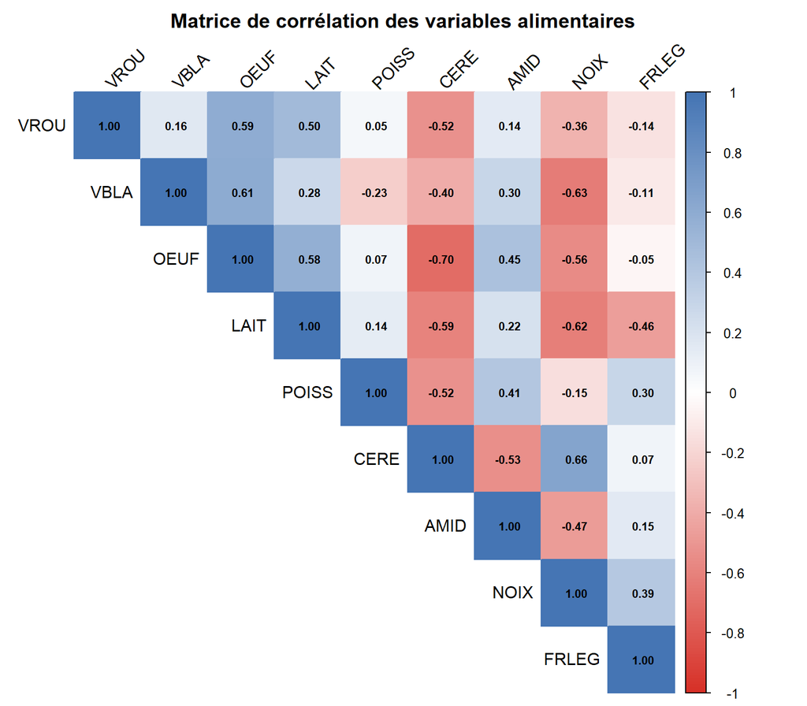

```r
library(corrplot)
corrplot(cor_matrix,
         method = "color",
         col = colorRampPalette(c("#D73027", "#FFFFFF", "#4575B4"))(200),
         type = "upper",
         tl.col = "black", tl.srt = 45,
         addCoef.col = "black", number.cex = 0.7,
         title = "Matrice de corrélation des variables alimentaires",
         mar = c(0, 0, 2, 0))
```

### 5.1.3 Question 2 : Variables corrélées / décorrélées

```r
cat("=== Corrélations positives fortes ===\n")
```

```
## === Corrélations positives fortes ===
```

```r
cat("  VBLA - OEUF :", round(cor_matrix["VBLA", "OEUF"], 3), "\n")
```

```
##   VBLA - OEUF : 0.608
```

```r
cat("  VROU - OEUF :", round(cor_matrix["VROU", "OEUF"], 3), "\n")
```

```
##   VROU - OEUF : 0.593
```

```r
cat("  LAIT - OEUF :", round(cor_matrix["LAIT", "OEUF"], 3), "\n\n")
```

```
##   LAIT - OEUF : 0.58
```

```r
cat("=== Corrélations négatives fortes ===\n")
```

```
## === Corrélations négatives fortes ===
```

```r
cat("  OEUF - CERE :", round(cor_matrix["OEUF", "CERE"], 3), "\n")
```

```
##   OEUF - CERE : -0.703
```

```r
cat("  LAIT - CERE :", round(cor_matrix["LAIT", "CERE"], 3), "\n\n")
```

```
##   LAIT - CERE : -0.593
```

```r
cat("=== Variables faiblement corrélées ===\n")
```

```
## === Variables faiblement corrélées ===
```

```r
cat("  FRLEG est relativement indépendante des autres variables.\n")
```

```
##   FRLEG est relativement indépendante des autres variables.
```

### 5.1.4 Question 3 : Graphiques de couples

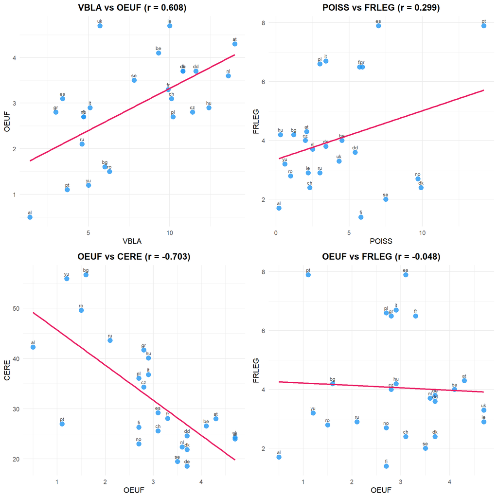

```r
library(ggplot2)
library(gridExtra)

plot_couple <- function(data, xvar, yvar, titre) {
  df <- data.frame(x = data[, xvar], y = data[, yvar], pays = rownames(data))
  r <- round(cor(df$x, df$y), 3)
  ggplot(df, aes(x = x, y = y)) +
    geom_point(color = "#2196F3", size = 3, alpha = 0.8) +
    geom_text(aes(label = pays), size = 2.5, vjust = -0.8, color = "gray30") +
    geom_smooth(method = "lm", color = "#E91E63", se = FALSE, linewidth = 1) +
    labs(title = paste0(titre, " (r = ", r, ")"), x = xvar, y = yvar) +
    theme_minimal() +
    theme(plot.title = element_text(hjust = 0.5, face = "bold", size = 13))
}

p1 <- plot_couple(donnees1, "VBLA", "OEUF", "VBLA vs OEUF")
p2 <- plot_couple(donnees1, "POISS", "FRLEG", "POISS vs FRLEG")
p3 <- plot_couple(donnees1, "OEUF", "CERE", "OEUF vs CERE")
p4 <- plot_couple(donnees1, "OEUF", "FRLEG", "OEUF vs FRLEG")

grid.arrange(p1, p2, p3, p4, ncol = 2)
```

**Commentaires :** VBLA vs OEUF montre une corrélation positive nette. OEUF vs CERE une forte corrélation négative (opposition produits animaux/céréales). POISS vs FRLEG et OEUF vs FRLEG sont faiblement corrélés. Le Portugal (pt) est atypique pour le poisson.

## 5.2 Partie 2 : ACP centrée-réduite

### 5.2.1 Question 4 : Résultats de l’ACP

```r
library(FactoMineR)
library(factoextra)

acp <- PCA(donnees1, scale.unit = TRUE, quali.sup = 10, ncp = 5, graph = FALSE)

cat("===== Valeurs propres =====\n")
```

```
## ===== Valeurs propres =====
```

```r
knitr::kable(round(acp$eig, 2),
             col.names = c("Val. propre", "% variance", "% cumulé"),
             caption = "Valeurs propres et variance expliquée")
```

Valeurs propres et variance expliquée

|  | Val. propre | % variance | % cumulé |
| --- | --- | --- | --- |
| comp 1 | 4.01 | 44.59 | 44.59 |
| comp 2 | 1.71 | 19.04 | 63.64 |
| comp 3 | 1.13 | 12.57 | 76.20 |
| comp 4 | 0.90 | 9.97 | 86.17 |
| comp 5 | 0.44 | 4.93 | 91.09 |
| comp 6 | 0.34 | 3.77 | 94.86 |
| comp 7 | 0.24 | 2.63 | 97.49 |
| comp 8 | 0.12 | 1.30 | 98.79 |
| comp 9 | 0.11 | 1.21 | 100.00 |

```r
cat("===== Corrélations variables / axes =====\n")
```

```
## ===== Corrélations variables / axes =====
```

```r
knitr::kable(round(acp$var$coord, 4), caption = "Corrélations des variables")
```

Corrélations des variables

|  | Dim.1 | Dim.2 | Dim.3 | Dim.4 | Dim.5 |
| --- | --- | --- | --- | --- | --- |
| VROU | 0.6228 | -0.1040 | -0.3164 | 0.6167 | 0.1889 |
| VBLA | 0.6118 | -0.2771 | 0.6751 | -0.0405 | -0.2242 |
| OEUF | 0.8495 | -0.0168 | 0.1967 | 0.3361 | -0.0086 |
| LAIT | 0.7612 | -0.2546 | -0.3927 | -0.0556 | -0.0779 |
| POISS | 0.2654 | 0.8093 | -0.3761 | -0.2173 | -0.2144 |
| CERE | -0.8746 | -0.2925 | 0.1330 | -0.0016 | 0.1665 |
| AMID | 0.5802 | 0.5069 | 0.2711 | -0.2621 | 0.5051 |
| NOIX | -0.8441 | 0.1594 | -0.0845 | 0.3438 | 0.0482 |
| FRLEG | -0.2560 | 0.7337 | 0.3773 | 0.4060 | -0.1417 |

```r
cat("===== Valeurs test de EST =====\n")
```

```
## ===== Valeurs test de EST =====
```

```r
print(round(acp$quali.sup$v.test[, 1:5], 2))
```

```
##   Dim.1 Dim.2 Dim.3 Dim.4 Dim.5
## 0  2.77  1.68 -1.89  1.67 -1.65
## 1 -2.77 -1.68  1.89 -1.67  1.65
```

```r
cat("===== Coordonnées des individus =====\n")
```

```
## ===== Coordonnées des individus =====
```

```r
knitr::kable(round(acp$ind$coord, 2), caption = "Coordonnées des individus")
```

Coordonnées des individus

|  | Dim.1 | Dim.2 | Dim.3 | Dim.4 | Dim.5 |
| --- | --- | --- | --- | --- | --- |
| al | -3.53 | -1.78 | -1.73 | 0.21 | 0.05 |
| at | 1.46 | -0.96 | 1.47 | 0.15 | -1.04 |
| be | 1.65 | 0.22 | 0.29 | 0.61 | 0.63 |
| bg | -3.19 | -1.34 | 0.21 | 0.16 | -0.47 |
| ch | 1.11 | -1.53 | -0.60 | 0.48 | -0.56 |
| cz | 0.38 | -0.51 | 1.33 | -0.43 | 0.26 |
| dd | 1.44 | 0.59 | 1.41 | -1.02 | 0.33 |
| de | 2.02 | -0.16 | 0.36 | 0.44 | 0.15 |
| dk | 2.42 | 0.30 | -0.67 | -1.02 | -0.80 |
| es | -1.35 | 2.85 | 0.50 | 0.56 | 0.41 |
| fi | 1.60 | -0.60 | -1.97 | -1.50 | 0.31 |
| fr | 1.50 | 0.78 | -0.03 | 1.91 | 0.15 |
| gr | -2.30 | 0.91 | -1.05 | 1.77 | -0.55 |
| hu | -1.49 | -0.74 | 2.02 | -0.11 | -0.20 |
| ie | 2.73 | -0.69 | 0.14 | 0.53 | 0.96 |
| it | -1.58 | 0.37 | 0.03 | 1.16 | -0.86 |
| nl | 1.68 | -0.85 | 0.89 | -0.16 | -0.80 |
| no | 1.00 | 0.79 | -1.71 | -1.20 | -0.34 |
| pl | 0.10 | 0.65 | 1.51 | -0.51 | 0.13 |
| pt | -1.80 | 4.30 | -0.26 | -0.93 | -0.40 |
| ro | -2.81 | -1.13 | 0.16 | -0.57 | 0.34 |
| ru | -0.81 | -0.07 | -0.27 | -0.83 | 1.80 |
| se | 1.68 | -0.23 | -1.22 | -0.79 | -0.84 |
| uk | 1.78 | -0.11 | -1.12 | 1.86 | 0.87 |
| yu | -3.70 | -1.05 | 0.28 | -0.78 | 0.45 |

```r
cat("===== Qualité de représentation (cos²) =====\n")
```

```
## ===== Qualité de représentation (cos²) =====
```

```r
knitr::kable(round(acp$ind$cos2, 4), caption = "cos² des individus")
```

cos² des individus

|  | Dim.1 | Dim.2 | Dim.3 | Dim.4 | Dim.5 |
| --- | --- | --- | --- | --- | --- |
| al | 0.6081 | 0.1547 | 0.1459 | 0.0022 | 0.0001 |
| at | 0.3275 | 0.1411 | 0.3331 | 0.0035 | 0.1653 |
| be | 0.7134 | 0.0126 | 0.0218 | 0.0982 | 0.1040 |
| bg | 0.7358 | 0.1309 | 0.0032 | 0.0018 | 0.0160 |
| ch | 0.2581 | 0.4914 | 0.0740 | 0.0479 | 0.0643 |
| cz | 0.0442 | 0.0827 | 0.5519 | 0.0587 | 0.0214 |
| dd | 0.3172 | 0.0523 | 0.3033 | 0.1595 | 0.0170 |
| de | 0.8088 | 0.0048 | 0.0255 | 0.0378 | 0.0044 |
| dk | 0.6732 | 0.0105 | 0.0517 | 0.1181 | 0.0737 |
| es | 0.1562 | 0.6950 | 0.0217 | 0.0266 | 0.0141 |
| fi | 0.2426 | 0.0346 | 0.3684 | 0.2155 | 0.0094 |
| fr | 0.2590 | 0.0702 | 0.0001 | 0.4184 | 0.0026 |
| gr | 0.4315 | 0.0670 | 0.0900 | 0.2555 | 0.0244 |
| hu | 0.2738 | 0.0668 | 0.4991 | 0.0014 | 0.0047 |
| ie | 0.7881 | 0.0501 | 0.0022 | 0.0301 | 0.0971 |
| it | 0.4572 | 0.0256 | 0.0002 | 0.2465 | 0.1354 |
| nl | 0.5183 | 0.1337 | 0.1465 | 0.0048 | 0.1164 |
| no | 0.1613 | 0.1023 | 0.4756 | 0.2349 | 0.0183 |
| pl | 0.0019 | 0.0854 | 0.4662 | 0.0526 | 0.0034 |
| pt | 0.1377 | 0.7831 | 0.0028 | 0.0366 | 0.0066 |
| ro | 0.8043 | 0.1311 | 0.0027 | 0.0328 | 0.0117 |
| ru | 0.1339 | 0.0009 | 0.0148 | 0.1417 | 0.6706 |
| se | 0.4784 | 0.0088 | 0.2493 | 0.1039 | 0.1189 |
| uk | 0.3465 | 0.0014 | 0.1357 | 0.3756 | 0.0821 |
| yu | 0.8626 | 0.0693 | 0.0051 | 0.0379 | 0.0126 |